# Survival Analysis for Colon Cancer Patients

#### *(2) The effect of gender on survival within the placebo, and in the treated cohorts*

This is tested by changing the predictor variable in surv() function to sex.

```r
par(mfrow=c(1,2))
#subset by placebo first

colon.subs <- colon_data
lev.sub <- subset(colon.subs,colon.subs$rx=="Lev+5FU")
obs.sub <- subset(colon.subs,colon.subs$rx=="Obs")

log.rank1 = survdiff(Surv(obs.sub$time,obs.sub$status)~obs.sub$sex)
log.rank1
```

```
## Call:
## survdiff(formula = Surv(obs.sub$time, obs.sub$status) ~ obs.sub$sex)
##
##                 N Observed Expected (O-E)^2/E (O-E)^2/V
## obs.sub$sex=0 149       81     82.8    0.0398    0.0749
## obs.sub$sex=1 166       96     94.2    0.0350    0.0749
##
##  Chisq= 0.1  on 1 degrees of freedom, p= 0.8
```

```r
ofit <- survfit(Surv(obs.sub$time,obs.sub$status)~obs.sub$sex)

plot(ofit,
     lty=c("solid","dashed"),
     col=c("black","blue"),
     xlab="survival time in days",
     ylab="survival probability")

title("Survival M vs. F (placebo)")

legend("topright",
c("Female","Male"),
lty=c("solid","dashed",
col="black","blue"))

###now for those with the drug

log.rank2 = survdiff(Surv(lev.sub$time,lev.sub$status)~lev.sub$sex)
log.rank2
```

```
## Call:
## survdiff(formula = Surv(lev.sub$time, lev.sub$status) ~ lev.sub$sex)
##
##                 N Observed Expected (O-E)^2/E (O-E)^2/V
## lev.sub$sex=0 163       74     59.6      3.48      6.98
## lev.sub$sex=1 141       45     59.4      3.49      6.98
##
##  Chisq= 7  on 1 degrees of freedom, p= 0.008
```

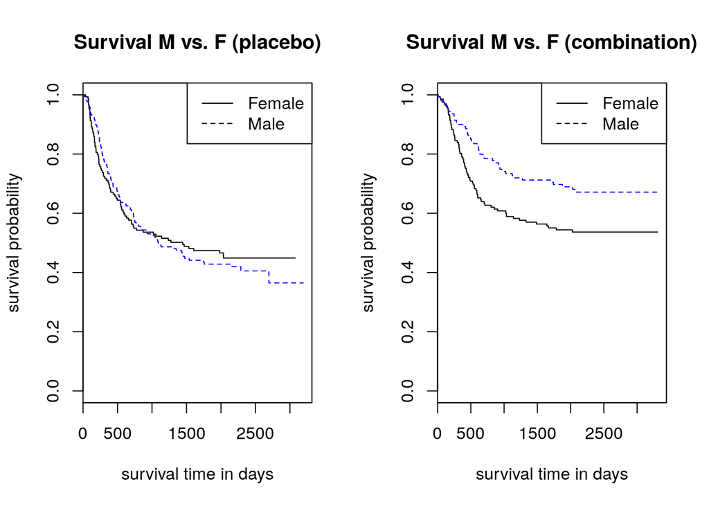

```r
lfit <- survfit(Surv(lev.sub$time,lev.sub$status)~lev.sub$sex)

plot(lfit,
     lty=c("solid","dashed"),
     col=c("black","blue"),
     xlab="survival time in days",
     ylab="survival probability")

title("Survival M vs. F (combination)")

legend("topright",
c("Female","Male"),
lty=c("solid","dashed",
col="black","blue"))
```

#### *(3) The impact having more than 4 positive sentinel lymph nodes to the resection location*

The predictor variable is replaced with node4.

```r
par(mfrow=c(1,2))
#subset by placebo first
log.rank3 = survdiff(Surv(obs.sub$time,obs.sub$status)~obs.sub$node4)
log.rank3
```

```
## Call:
## survdiff(formula = Surv(obs.sub$time, obs.sub$status) ~ obs.sub$node4)
##
##                   N Observed Expected (O-E)^2/E (O-E)^2/V
## obs.sub$node4=0 228      114    140.6      5.03      24.7
## obs.sub$node4=1  87       63     36.4     19.42      24.7
##
##  Chisq= 24.7  on 1 degrees of freedom, p= 7e-07
```

```r
nfit <- survfit(Surv(obs.sub$time,obs.sub$status)~obs.sub$node4)

plot(nfit,
     lty=c("solid","dashed"),
     col=c("black","blue"),
     xlab="survival time in days",
     ylab="survival probability")

title("Effect of 4+ LN (Placebo)")

legend("topright",
c("Not present","Present"),
lty=c("solid","dashed",
col="black","blue"))

###now for those with the drug

log.rank4 = survdiff(Surv(lev.sub$time,lev.sub$status)~lev.sub$node4)
log.rank4
```

```
## Call:
## survdiff(formula = Surv(lev.sub$time, lev.sub$status) ~ lev.sub$node4)
##
##                   N Observed Expected (O-E)^2/E (O-E)^2/V
## lev.sub$node4=0 225       70     94.8      6.48        32
## lev.sub$node4=1  79       49     24.2     25.38        32
##
##  Chisq= 32  on 1 degrees of freedom, p= 2e-08
```

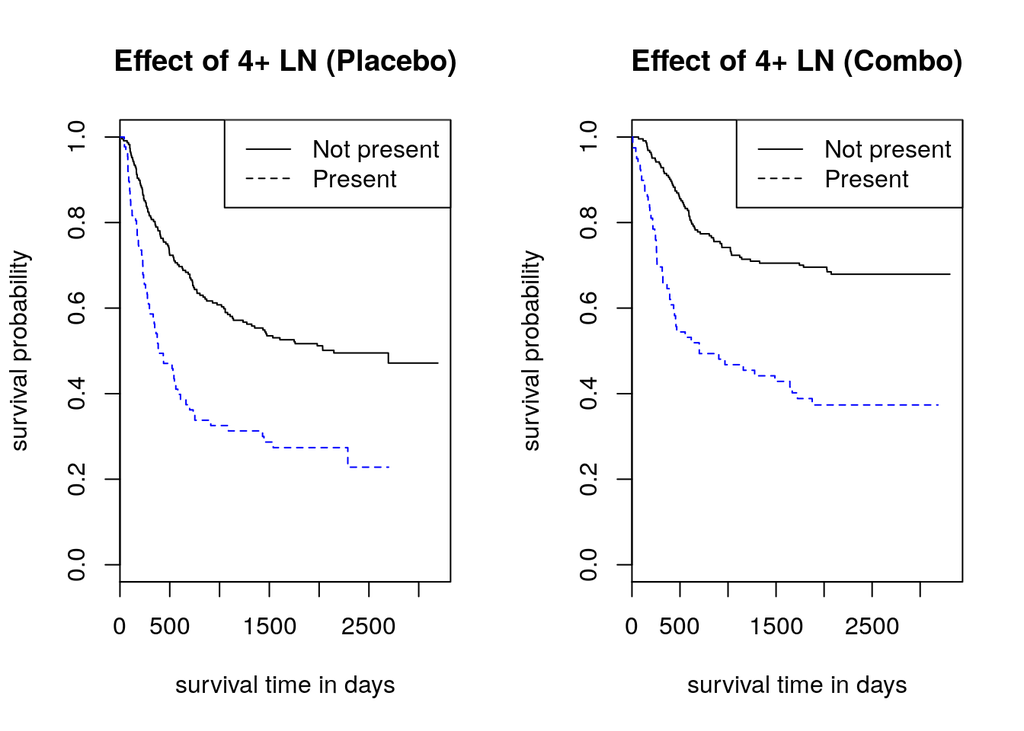

```r
n1fit <- survfit(Surv(lev.sub$time,lev.sub$status)~lev.sub$node4)

plot(n1fit,
     lty=c("solid","dashed"),
     col=c("black","blue"),
     xlab="survival time in days",
     ylab="survival probability")

title("Effect of 4+ LN (Combo)")

legend("topright",
c("Not present","Present"),
lty=c("solid","dashed",
col="black","blue"))
```

The results indicate that probabiltiy of survival is much higher in the absence of 4+ sentinel lymph node. The log rank indicates that the chances of survival are greatly improved also. The probability of survival is only slightly increased in the presence of LM. However if the patient does not have 4 or more proximal LM and the are recieving combination treatment then their probability of survival is greatly improved. The greatest benefit for those who have 4 or more LM is that their survival time is improved but their prognosis is still bad. From this data, we can reject the null hypothesis that there is no difference in survival as it is obvious. This information is useful in decision making on how to proceed with cancers that are effected by lymph node proximity. Research into breast cancer survival following sentinel lymph node biopsy has indicated that there was no difference in survival between control groups and those who had the surgery. Using survival analysis for breast cancer or colorectal carcinoma following drug treatment or surgery in useful in finding the most effective treatment for increase survival probability and length.